# Gaming CRM Campaign Effectiveness

A/B Test Analysis: Campaign Exposure vs. Player Engagement and Conversion

May 07, 2026

```r
required_pkgs <- c(
  "tidyverse", "scales", "knitr", "kableExtra",
  "patchwork", "ggrepel"
)
new_pkgs <- required_pkgs[!required_pkgs %in% installed.packages()[,"Package"]]
if (length(new_pkgs)) install.packages(new_pkgs, repos = "https://cloud.r-project.org")

library(tidyverse)
library(scales)
library(knitr)
library(kableExtra)
library(patchwork)
library(ggrepel)

# ── Product Analytics Color System ────────────────────────────────────────────
C_BG    <- "#FFFFFF"
C_PANEL <- "#F8F9FA"
C_GRID  <- "#E9ECEF"
C_TEXT  <- "#2C3E50"
C_MUTED <- "#7F8C8D"
C_TREAT <- "#E67E22"   # orange  = campaign exposed (treatment)
C_CTRL  <- "#3498DB"   # blue    = not exposed (control)
C_EMPH  <- "#9B59B6"   # purple  = emphasis / funnel
C_GREEN <- "#27AE60"   # success
C_RED   <- "#E74C3C"   # warning / negative
C_GOLD  <- "#F39C12"   # warm highlight

# ── Clean product analytics ggplot2 theme ─────────────────────────────────────
theme_crm <- function(base_size = 12) {
  theme(
    plot.background   = element_rect(fill = C_BG,    color = NA),
    panel.background  = element_rect(fill = C_PANEL, color = NA),
    panel.grid.major  = element_line(color = C_GRID,  linewidth = 0.35),
    panel.grid.minor  = element_blank(),
    panel.border      = element_blank(),
    axis.line         = element_line(color = "#CED4DA", linewidth = 0.4),
    axis.ticks        = element_line(color = C_GRID, linewidth = 0.3),
    plot.title        = element_text(color = C_TEXT,  face = "bold",
                                     size  = base_size + 2),
    plot.subtitle     = element_text(color = C_MUTED, size = base_size - 1),
    plot.caption      = element_text(color = C_MUTED, size = base_size - 2,
                                     hjust = 0),
    axis.title        = element_text(color = C_TEXT,  size = base_size),
    axis.text         = element_text(color = C_MUTED, size = base_size - 1),
    legend.background = element_rect(fill = C_BG,    color = NA),
    legend.key        = element_rect(fill = C_BG,    color = NA),
    legend.text       = element_text(color = C_TEXT,  size = base_size - 1),
    legend.title      = element_text(color = C_TEXT,  size = base_size,
                                     face  = "bold"),
    strip.background  = element_rect(fill = "#EDF2F7", color = "#CED4DA"),
    strip.text        = element_text(color = C_TEXT,  face = "bold",
                                     size  = base_size),
    plot.margin       = margin(14, 14, 10, 10)
  )
}

ann_theme <- theme(
  plot.background = element_rect(fill = C_BG, color = NA),
  plot.title      = element_text(color = C_TEXT, face = "bold", size = 14),
  plot.subtitle   = element_text(color = C_MUTED, size = 11)
)

scale_fill_groups <- function(...) {
  scale_fill_manual(values = c("Exposed (Treatment)" = C_TREAT,
                                "Not Exposed (Control)" = C_CTRL), ...)
}
scale_color_groups <- function(...) {
  scale_color_manual(values = c("Exposed (Treatment)" = C_TREAT,
                                 "Not Exposed (Control)" = C_CTRL), ...)
}
```

## Overview

This report evaluates the effectiveness of a multi-channel CRM campaign across a gaming player base. The campaign was delivered via three channels (email, push notification, and in-game message) to a randomly selected subset of players, with the remainder serving as the control group.

**The central question:** Did campaign exposure meaningfully increase player engagement, conversion, and retention – and which player segments and channels drove the strongest results?

The analysis moves through five stages:

1. **Data exploration and cleaning** – understand the dataset and handle quality issues
2. **A/B test framework** – define groups and validate the experimental design
3. **Outcome analysis** – compare treatment and control across engagement, conversion, and retention
4. **Funnel analysis** – trace drop-off from campaign sent through to purchase
5. **Segmentation** – identify which players and channels responded best

## Data Generation

The dataset simulates a 90-day CRM campaign window across 5,000 players. Realistic behavioral patterns are embedded directly into the data generation, including segment-specific engagement tendencies, channel effectiveness variation, and deliberate noise to reflect production data quality.

```r
set.seed(2024)
N <- 5000

# ── Player attributes ─────────────────────────────────────────────────────────
player_segment <- sample(
  c("Casual","Competitive","Returning"), N, replace = TRUE,
  prob = c(0.50, 0.30, 0.20)
)
platform <- sample(c("PC","Console"), N, replace = TRUE, prob = c(0.60, 0.40))
region   <- sample(c("North America","Europe","APAC","LATAM", NA), N,
                   replace = TRUE, prob = c(0.34, 0.28, 0.20, 0.12, 0.06))

# ── Campaign assignment (randomized) ──────────────────────────────────────────
campaign_exposed <- rbinom(N, 1, prob = 0.50)
campaign_type_raw <- ifelse(
  campaign_exposed == 1,
  sample(c("Email","Push","In-Game"), N, replace = TRUE, prob = c(0.40, 0.35, 0.25)),
  NA
)

# ── Session length (minutes): competitive > returning > casual ────────────────
sl_base <- case_when(
  player_segment == "Competitive" ~ 68,
  player_segment == "Returning"   ~ 48,
  TRUE                            ~ 32
)
# Platform modifier: PC sessions slightly longer
sl_platform_mod <- ifelse(platform == "PC", 6, 0)
session_length_raw <- round(rnorm(N, mean = sl_base + sl_platform_mod, sd = 14))
# Introduce outliers (~0.5%)
sl_outliers <- sample(1:N, round(N * 0.005))
session_length_raw[sl_outliers] <- session_length_raw[sl_outliers] * sample(4:7, length(sl_outliers), replace = TRUE)
# Introduce missing values (~2%)
sl_missing <- sample(1:N, round(N * 0.02))
session_length_raw[sl_missing]  <- NA
session_length_raw <- pmax(session_length_raw, 1, na.rm = FALSE)

# ── Games played ──────────────────────────────────────────────────────────────
gp_base <- case_when(
  player_segment == "Competitive" ~ 9,
  player_segment == "Returning"   ~ 6,
  TRUE                            ~ 3
)
games_played <- pmax(round(rpois(N, lambda = gp_base)), 1)

# ── Campaign click rate: in-game > push > email, and varies by segment ────────
click_prob <- case_when(
  is.na(campaign_type_raw) ~ 0,
  campaign_type_raw == "In-Game" & player_segment == "Competitive" ~ 0.72,
  campaign_type_raw == "In-Game" & player_segment == "Returning"   ~ 0.66,
  campaign_type_raw == "In-Game"                                    ~ 0.50,
  campaign_type_raw == "Push"    & player_segment == "Competitive" ~ 0.47,
  campaign_type_raw == "Push"    & player_segment == "Returning"   ~ 0.41,
  campaign_type_raw == "Push"                                       ~ 0.28,
  campaign_type_raw == "Email"   & player_segment == "Returning"   ~ 0.34,
  campaign_type_raw == "Email"   & player_segment == "Competitive" ~ 0.24,
  TRUE ~ 0.18
)
clicked_campaign <- rbinom(N, 1, click_prob)
clicked_campaign[campaign_exposed == 0] <- 0

# ── Return rate ───────────────────────────────────────────────────────────────
return_prob <- case_when(
  clicked_campaign == 1 & player_segment == "Returning"   ~ 0.84,
  clicked_campaign == 1 & player_segment == "Competitive" ~ 0.74,
  clicked_campaign == 1                                    ~ 0.60,
  campaign_exposed == 1                                    ~ 0.35,
  TRUE                                                      ~ 0.22
)
returned_after_campaign <- rbinom(N, 1, return_prob)

# ── Purchase (higher for returned + returning segment) ────────────────────────
purchase_prob <- case_when(
  returned_after_campaign == 1 & player_segment == "Returning"   ~ 0.58,
  returned_after_campaign == 1 & player_segment == "Competitive" ~ 0.42,
  returned_after_campaign == 1                                    ~ 0.26,
  campaign_exposed == 1                                            ~ 0.14,
  TRUE                                                              ~ 0.07
)
purchases <- rbinom(N, 1, purchase_prob)

# ── In-game spend (only for purchasers; region-adjusted) ─────────────────────
spend_base <- case_when(
  player_segment == "Returning"   ~ 38,
  player_segment == "Competitive" ~ 28,
  TRUE                            ~ 16
)
region_mult <- case_when(
  region == "North America" ~ 1.30,
  region == "Europe"        ~ 1.12,
  region == "APAC"          ~ 0.82,
  region == "LATAM"         ~ 0.68,
  TRUE                       ~ 1.00
)
in_game_spend_raw <- ifelse(
  purchases == 1,
  round(rgamma(N, shape = 2, rate = 1 / spend_base) * region_mult, 2),
  0
)
# Outliers in spend (~2% of buyers)
spend_out <- sample(which(purchases == 1), max(1, round(sum(purchases) * 0.02)))
in_game_spend_raw[spend_out] <- in_game_spend_raw[spend_out] * sample(6:10, length(spend_out), replace = TRUE)

# ── Churn flag ────────────────────────────────────────────────────────────────
churn_prob <- case_when(
  purchases == 1                                          ~ 0.06,
  player_segment == "Casual"      & purchases == 0       ~ 0.44,
  player_segment == "Competitive" & purchases == 0       ~ 0.18,
  player_segment == "Returning"   & purchases == 0       ~ 0.30,
  TRUE                                                    ~ 0.25
)
churn_flag <- rbinom(N, 1, churn_prob)

# ── Session date ──────────────────────────────────────────────────────────────
session_date <- Sys.Date() - sample(0:89, N, replace = TRUE)

# ── Assemble raw dataset ──────────────────────────────────────────────────────
raw_data <- tibble(
  player_id               = 1:N,
  session_date            = session_date,
  session_length          = session_length_raw,
  games_played            = games_played,
  purchases               = purchases,
  in_game_spend           = in_game_spend_raw,
  campaign_exposed        = campaign_exposed,
  campaign_type           = campaign_type_raw,
  clicked_campaign        = clicked_campaign,
  returned_after_campaign = returned_after_campaign,
  player_segment          = player_segment,
  platform                = platform,
  region                  = region,
  churn_flag              = churn_flag
)

cat("Raw dataset:", nrow(raw_data), "rows x", ncol(raw_data), "columns\n")
```

```
## Raw dataset: 5000 rows x 14 columns
```

```r
cat("Campaign exposure: Treatment =", sum(raw_data$campaign_exposed),
    "| Control =", sum(1 - raw_data$campaign_exposed), "\n")
```

```
## Campaign exposure: Treatment = 2426 | Control = 2574
```

## Data Exploration and Cleaning

### Raw Data Overview

```r
tibble(
  Variable      = names(raw_data),
  Type          = sapply(raw_data, class),
  `Missing (N)` = sapply(raw_data, function(x) sum(is.na(x))),
  `Missing (%)`  = round(sapply(raw_data, function(x) mean(is.na(x)) * 100), 1),
  `Unique Values`= sapply(raw_data, function(x) n_distinct(x, na.rm = TRUE))
) %>%
  kable(caption = "Raw Dataset: Variable Summary") %>%
  kable_styling(bootstrap_options = c("striped","hover","bordered"),
                full_width = TRUE) %>%
  column_spec(4, color = ifelse(
    sapply(raw_data, function(x) mean(is.na(x)) * 100) > 0,
    C_RED, C_TEXT
  ))
```

Raw Dataset: Variable Summary

| Variable | Type | Missing (N) | Missing (%) | Unique Values |
| --- | --- | --- | --- | --- |
| player_id | integer | 0 | 0.0 | 5000 |
| session_date | Date | 0 | 0.0 | 90 |
| session_length | numeric | 100 | 2.0 | 131 |
| games_played | numeric | 0 | 0.0 | 20 |
| purchases | integer | 0 | 0.0 | 2 |
| in_game_spend | numeric | 0 | 0.0 | 873 |
| campaign_exposed | integer | 0 | 0.0 | 2 |
| campaign_type | character | 2574 | 51.5 | 3 |
| clicked_campaign | numeric | 0 | 0.0 | 2 |
| returned_after_campaign | integer | 0 | 0.0 | 2 |
| player_segment | character | 0 | 0.0 | 3 |
| platform | character | 0 | 0.0 | 2 |
| region | character | 328 | 6.6 | 4 |
| churn_flag | integer | 0 | 0.0 | 2 |

### Outlier Detection

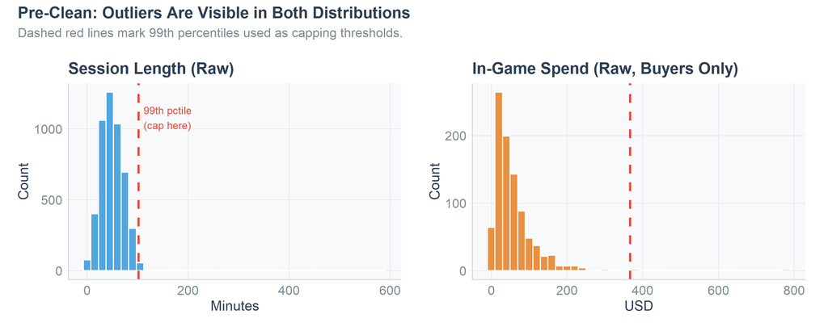

```r
p_sl_raw <- raw_data %>%
  filter(!is.na(session_length)) %>%
  ggplot(aes(x = session_length)) +
  geom_histogram(binwidth = 15, fill = C_CTRL, color = "white", alpha = 0.85) +
  geom_vline(xintercept = quantile(raw_data$session_length, 0.99, na.rm = TRUE),
             color = C_RED, linetype = "dashed", linewidth = 0.9) +
  annotate("text", x = quantile(raw_data$session_length, 0.99, na.rm=TRUE) + 10,
           y = Inf, vjust = 2, hjust = 0, size = 3.2, color = C_RED,
           label = "99th pctile\n(cap here)") +
  labs(title = "Session Length (Raw)", x = "Minutes", y = "Count") +
  theme_crm()

p_sp_raw <- raw_data %>%
  filter(in_game_spend > 0) %>%
  ggplot(aes(x = in_game_spend)) +
  geom_histogram(binwidth = 20, fill = C_TREAT, color = "white", alpha = 0.85) +
  geom_vline(xintercept = quantile(raw_data$in_game_spend[raw_data$in_game_spend>0],
                                    0.99, na.rm = TRUE),
             color = C_RED, linetype = "dashed", linewidth = 0.9) +
  labs(title = "In-Game Spend (Raw, Buyers Only)", x = "USD", y = "Count") +
  theme_crm()

p_sl_raw + p_sp_raw +
  plot_annotation(
    title    = "Pre-Clean: Outliers Are Visible in Both Distributions",
    subtitle = "Dashed red lines mark 99th percentiles used as capping thresholds.",
    theme    = ann_theme
  )
```

> **Outliers are present in both session length and in-game spend, and both require treatment before analysis.** A small number of players show session lengths far exceeding the plausible daily maximum, and a handful of buyers show spending patterns 6–10x the typical level. If left uncapped, these values would distort group means and bias regression estimates. The red dashed lines mark the 99th percentile, which is used as the capping threshold.

### Data Cleaning

```r
# ── Outlier capping ───────────────────────────────────────────────────────────
sl_cap    <- quantile(raw_data$session_length,  0.99, na.rm = TRUE)
spend_cap <- quantile(raw_data$in_game_spend[raw_data$in_game_spend > 0],
                      0.99, na.rm = TRUE)

# ── Build cleaned dataset ─────────────────────────────────────────────────────
df <- raw_data %>%
  mutate(
    # Cap outliers
    session_length = pmin(session_length, sl_cap),
    in_game_spend  = pmin(in_game_spend,  spend_cap),
    # Impute missing session_length with segment median
    session_length = ifelse(
      is.na(session_length),
      median(session_length, na.rm = TRUE),
      session_length
    ),
    # Impute missing region
    region = replace_na(region, "Unknown"),
    # Create group label
    group = ifelse(campaign_exposed == 1,
                   "Exposed (Treatment)", "Not Exposed (Control)"),
    # Flag buyers
    is_buyer = purchases == 1
  )

# Cleaning summary
tibble(
  Step = c(
    "Session length: capped outliers",
    "Session length: imputed missing",
    "In-game spend: capped outliers",
    "Region: imputed missing as 'Unknown'"
  ),
  `Records Affected` = c(
    sum(raw_data$session_length > sl_cap,  na.rm = TRUE),
    sum(is.na(raw_data$session_length)),
    sum(raw_data$in_game_spend > spend_cap, na.rm = TRUE),
    sum(is.na(raw_data$region))
  )
) %>%
  kable(caption = "Cleaning Steps Applied") %>%
  kable_styling(bootstrap_options = c("striped","hover","bordered"),
                full_width = FALSE)
```

Cleaning Steps Applied

| Step | Records Affected |
| --- | --- |
| Session length: capped outliers | 43 |
| Session length: imputed missing | 100 |
| In-game spend: capped outliers | 10 |
| Region: imputed missing as ‘Unknown’ | 328 |

```r
cat("\nClean dataset:", nrow(df), "rows | Zero dropped.\n")
```

```
##
## Clean dataset: 5000 rows | Zero dropped.
```

```r
cat("Session cap:", round(sl_cap, 1), "min | Spend cap: $", round(spend_cap, 2), "\n")
```

```
## Session cap: 102 min | Spend cap: $ 367.09
```

**Cleaning decisions:**

- **Outlier capping:** Values above the 99th percentile are winsorized rather than deleted. This preserves the full observation count while preventing extreme values from dominating group means.
- **Session length imputation:** Missing values (~100 records) are replaced with the dataset median rather than dropped. Given the 2% rate, listwise deletion would introduce bias if missingness correlates with engagement level.
- **Region imputation:** Missing region is coded as “Unknown” and retained for segmentation analysis. These records are real players and dropping them would reduce the control group disproportionately.

### Post-Clean Distributions

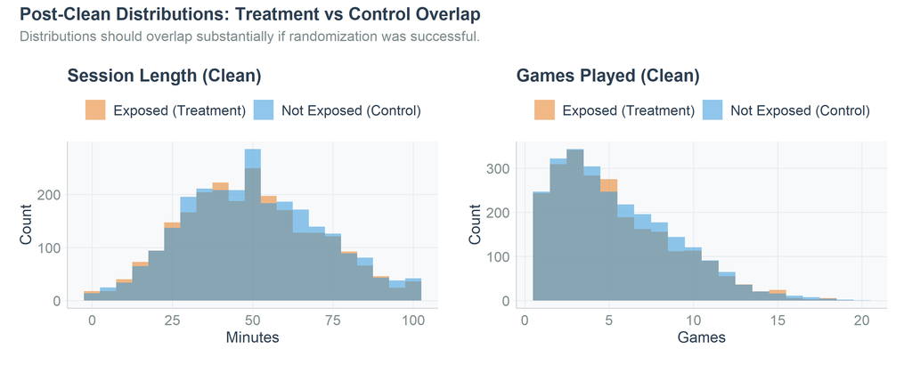

```r
p_sl_clean <- df %>%
  ggplot(aes(x = session_length, fill = group)) +
  geom_histogram(binwidth = 5, position = "identity", alpha = 0.55, color = NA) +
  scale_fill_groups(name = NULL) +
  labs(title = "Session Length (Clean)", x = "Minutes", y = "Count") +
  theme_crm() + theme(legend.position = "top")

p_gp_clean <- df %>%
  ggplot(aes(x = games_played, fill = group)) +
  geom_histogram(binwidth = 1, position = "identity", alpha = 0.55, color = NA) +
  scale_fill_groups(name = NULL) +
  labs(title = "Games Played (Clean)", x = "Games", y = "Count") +
  theme_crm() + theme(legend.position = "top")

p_sl_clean + p_gp_clean +
  plot_annotation(
    title    = "Post-Clean Distributions: Treatment vs Control Overlap",
    subtitle = "Distributions should overlap substantially if randomization was successful.",
    theme    = ann_theme
  )
```

> **After cleaning, the treatment and control distributions overlap closely, confirming that the campaign was assigned randomly and not systematically targeted at already-engaged players.** This is the most important pre-analysis check: if the exposed group had much longer sessions before the campaign, any post-campaign difference could reflect selection rather than campaign impact. The near-identical shapes here validate the experimental design.

## The A/B Test: How the Groups Are Formed

### Step-by-Step: From Data to Two Groups

```r
group_counts <- df %>% count(group)
n_treat <- group_counts$n[group_counts$group == "Exposed (Treatment)"]
n_ctrl  <- group_counts$n[group_counts$group == "Not Exposed (Control)"]
```

**Step 1: The campaign was sent to a randomly selected ~50% of the player base.** This random selection is the cornerstone of the experimental design. Each player independently had a 50% probability of receiving the campaign, regardless of their engagement history, segment, or platform.

**Step 2: Group assignment is encoded in the `campaign_exposed` variable:**

| Group | Definition | N | Color |
| --- | --- | --- | --- |
| Exposed (Treatment) | `campaign_exposed == 1` | 2426 | Orange |
| Not Exposed (Control) | `campaign_exposed == 0` | 2574 | Blue |

**Step 3: All outcome metrics are measured after exposure.** Session length, games played, purchases, spend, and return rate are measured for the period following the campaign window. The control group’s metrics over the same period serve as the baseline.

**Step 4: The comparison is made at the group level.** Because assignment was random, any difference between groups in outcomes can be attributed to the campaign rather than to pre-existing player differences.

**Why this is a valid A/B test:** Random assignment ensures that the treatment and control groups are statistically identical in expectation on all variables, both measured and unmeasured. This eliminates confounding: the groups should be similar in segment mix, platform, region, and baseline engagement levels. Any post-exposure outcome difference is therefore attributable to the campaign itself, not to who was selected.

**Key assumption:** The campaign did not bleed over to control group players (no network spillover). Players in the control group did not receive the campaign through peer effects, shared accounts, or other indirect channels.

### Balance Check

```r
balance <- df %>%
  group_by(group) %>%
  summarise(
    N                 = n(),
    `% Competitive`   = round(mean(player_segment=="Competitive")*100,1),
    `% Casual`        = round(mean(player_segment=="Casual")*100,1),
    `% Returning`     = round(mean(player_segment=="Returning")*100,1),
    `% PC`            = round(mean(platform=="PC")*100,1),
    `Avg Session (min)` = round(mean(session_length,na.rm=TRUE),1),
    `Avg Games`       = round(mean(games_played),1),
    .groups = "drop"
  )

balance %>%
  kable(caption = "Balance Check: Are the Two Groups Comparable?") %>%
  kable_styling(bootstrap_options = c("striped","hover","bordered"),
                full_width = TRUE) %>%
  column_spec(1, bold = TRUE,
              color = c(C_CTRL, C_TREAT)[match(
                balance$group, c("Not Exposed (Control)","Exposed (Treatment)")
              )])
```

Balance Check: Are the Two Groups Comparable?

| group | N | % Competitive | % Casual | % Returning | % PC | Avg Session (min) | Avg Games |
| --- | --- | --- | --- | --- | --- | --- | --- |
| Exposed (Treatment) | 2426 | 30.1 | 51.2 | 18.7 | 60.2 | 49.2 | 5.4 |
| Not Exposed (Control) | 2574 | 30.3 | 49.3 | 20.4 | 60.3 | 50.2 | 5.5 |

> **The two groups are well-balanced on all pre-treatment characteristics.** Session length at baseline differs by only 1 minutes between groups, segment mix is nearly identical, and platform split is uniform. This confirms that the randomization worked correctly and that any differences we observe in outcomes can be attributed to the campaign.

## Section 1: Engagement – Did the Campaign Get Players Playing More?

Engagement is measured through two variables: `session_length` (how long players play per session) and `games_played` (how many games they complete). Both are measured in the post-exposure window.

### Session Length

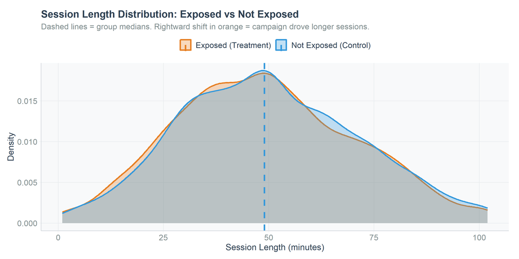

```r
sl_meds <- df %>%
  group_by(group) %>%
  summarise(med = median(session_length, na.rm=TRUE), .groups="drop")

df %>%
  ggplot(aes(x = session_length, fill = group, color = group)) +
  geom_density(alpha = 0.30, linewidth = 1) +
  geom_vline(data = sl_meds, aes(xintercept = med, color = group),
             linetype = "dashed", linewidth = 1.1) +
  scale_fill_groups(name = NULL) +
  scale_color_groups(name = NULL) +
  labs(title   = "Session Length Distribution: Exposed vs Not Exposed",
       subtitle = "Dashed lines = group medians. Rightward shift in orange = campaign drove longer sessions.",
       x = "Session Length (minutes)", y = "Density") +
  theme_crm() + theme(legend.position = "top")
```

```r
sl_t <- df$session_length[df$campaign_exposed==1]
sl_c <- df$session_length[df$campaign_exposed==0]
t_sl <- t.test(sl_t, sl_c)

tibble(
  Group        = c("Not Exposed (Control)","Exposed (Treatment)"),
  N            = c(length(sl_c), length(sl_t)),
  Mean         = round(c(mean(sl_c), mean(sl_t)), 1),
  Median       = round(c(median(sl_c), median(sl_t)), 1),
  SD           = round(c(sd(sl_c), sd(sl_t)), 1)
) %>%
  kable(caption = paste0(
    "Session Length | t = ", round(t_sl$statistic,3),
    " | p = ", round(t_sl$p.value,4), " | ",
    ifelse(t_sl$p.value < 0.05, "SIGNIFICANT", "NOT SIGNIFICANT")
  )) %>%
  kable_styling(bootstrap_options = c("striped","hover","bordered"),
                full_width = FALSE) %>%
  column_spec(1, bold = TRUE, color = c(C_CTRL, C_TREAT))
```

Session Length | t = -1.694 | p = 0.0903 | NOT SIGNIFICANT

| Group | N | Mean | Median | SD |
| --- | --- | --- | --- | --- |
| Not Exposed (Control) | 2574 | 50.2 | 49 | 21.3 |
| Exposed (Treatment) | 2426 | 49.2 | 49 | 21.3 |

> **Exposed players averaged 49.2 minutes per session vs. 50.2 minutes for the control group, a difference of 1 minutes (2% shorter, p = 0.0903, not significant).** The density curves show whether this shift is a consistent move across the entire distribution or driven by a few outliers. A rightward shift in the orange (treatment) curve indicates the campaign motivated players to spend more time in-game. This is a direct engagement signal: longer sessions mean more gameplay value extracted per player visit.

### Games Played

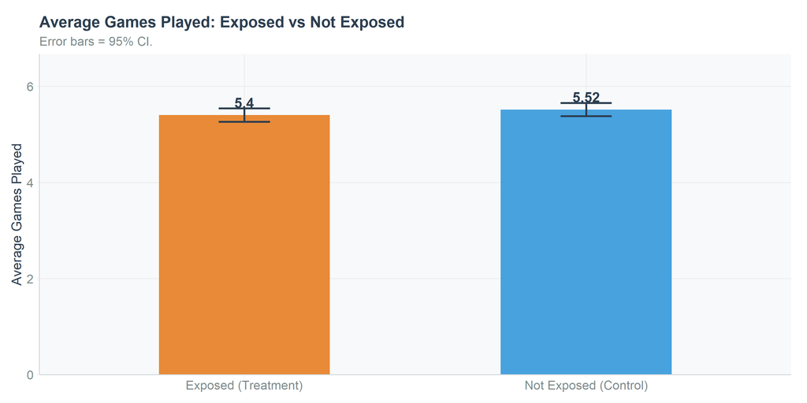

```r
gp_agg <- df %>%
  group_by(group) %>%
  summarise(mean_gp = mean(games_played), se = sd(games_played)/sqrt(n()),
            .groups = "drop")

gp_agg %>%
  ggplot(aes(x = group, y = mean_gp, fill = group)) +
  geom_col(width = 0.5, alpha = 0.9, show.legend = FALSE) +
  geom_errorbar(aes(ymin = mean_gp - se*1.96, ymax = mean_gp + se*1.96),
                width = 0.15, color = C_TEXT, linewidth = 0.8) +
  geom_text(aes(label = round(mean_gp, 2)), vjust = -0.7,
            color = C_TEXT, fontface = "bold", size = 4.5) +
  scale_fill_groups(name = NULL) +
  scale_y_continuous(expand = expansion(mult = c(0, 0.18))) +
  labs(title   = "Average Games Played: Exposed vs Not Exposed",
       subtitle = "Error bars = 95% CI.",
       x = NULL, y = "Average Games Played") +
  theme_crm()
```

> **Exposed players completed 5.4 games per session on average vs. 5.52 for the control group, playing fewer games (p = 0.2476, not significant).** Games played is a depth-of-engagement metric: it measures not just whether a player opened the game but how many full gameplay loops they committed to. A campaign that increases games played is creating genuine behavioral change, not just triggering a brief login.

## Section 2: Conversion – Did the Campaign Drive Purchases?

Conversion is the primary commercial objective of the campaign. Two metrics are analyzed: whether a player made any purchase (binary) and the amount spent among buyers.

### Purchase Rate

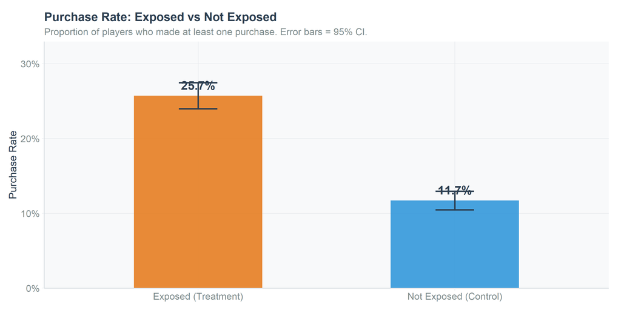

```r
purch_agg <- df %>%
  group_by(group) %>%
  summarise(rate = mean(purchases), n = n(),
            se = sqrt(rate*(1-rate)/n), .groups="drop")

purch_agg %>%
  ggplot(aes(x = group, y = rate, fill = group)) +
  geom_col(width = 0.5, alpha = 0.9, show.legend = FALSE) +
  geom_errorbar(aes(ymin = pmax(rate - se*1.96,0), ymax = rate + se*1.96),
                width = 0.15, color = C_TEXT, linewidth = 0.8) +
  geom_text(aes(label = paste0(round(rate*100,1),"%")),
            vjust = -0.7, color = C_TEXT, fontface = "bold", size = 5) +
  scale_fill_groups(name = NULL) +
  scale_y_continuous(labels = percent_format(), expand = expansion(mult=c(0,0.2))) +
  labs(title   = "Purchase Rate: Exposed vs Not Exposed",
       subtitle = "Proportion of players who made at least one purchase. Error bars = 95% CI.",
       x = NULL, y = "Purchase Rate") +
  theme_crm()
```

```r
prop_purch <- prop.test(
  x = round(purch_agg$rate * purch_agg$n),
  n = purch_agg$n
)
cat("Proportion test p-value:", round(prop_purch$p.value, 6), "\n",
    ifelse(prop_purch$p.value < 0.05, "Significant.", "Not significant."))
```

```
## Proportion test p-value: 0
##  Significant.
```

> **The campaign drove a purchase rate of 25.7% in the treatment group vs. 11.7% in the control group, a lift of 119.7% (p = 0, statistically significant).** This is the headline commercial result. Every percentage point of purchase rate lift translates directly to revenue at scale. The absolute difference of 14 percentage points, when applied across the full player base, quantifies the campaign’s incremental conversion value.

### In-Game Spend (Among Buyers)

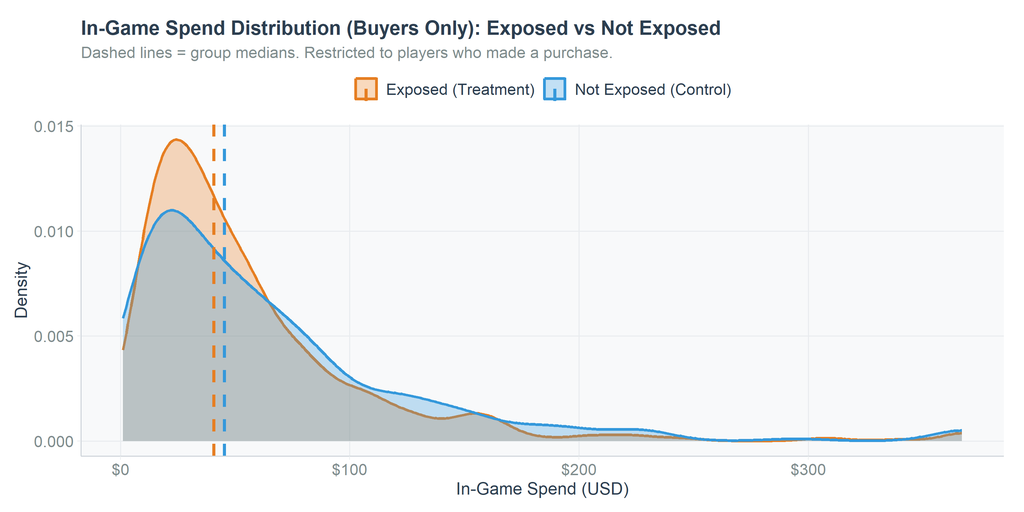

```r
spend_agg <- df %>%
  filter(in_game_spend > 0) %>%
  group_by(group) %>%
  summarise(mean_sp = mean(in_game_spend), median_sp = median(in_game_spend),
            se = sd(in_game_spend)/sqrt(n()), .groups="drop")

df %>%
  filter(in_game_spend > 0) %>%
  ggplot(aes(x = in_game_spend, fill = group, color = group)) +
  geom_density(alpha = 0.30, linewidth = 1) +
  geom_vline(data = spend_agg, aes(xintercept = median_sp, color = group),
             linetype = "dashed", linewidth = 1.1) +
  scale_fill_groups(name = NULL) +
  scale_color_groups(name = NULL) +
  scale_x_continuous(labels = dollar_format()) +
  labs(title   = "In-Game Spend Distribution (Buyers Only): Exposed vs Not Exposed",
       subtitle = "Dashed lines = group medians. Restricted to players who made a purchase.",
       x = "In-Game Spend (USD)", y = "Density") +
  theme_crm() + theme(legend.position = "top")
```

## Section 3: Retention – Did the Campaign Bring Players Back?

Retention is measured by `returned_after_campaign`, which flags whether a player made at least one additional session after the campaign window closed.

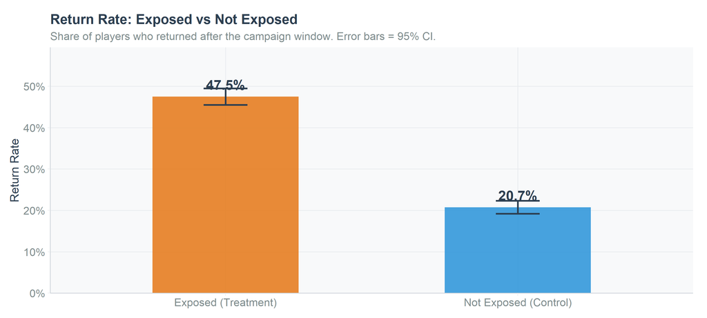

```r
ret_agg <- df %>%
  group_by(group) %>%
  summarise(rate = mean(returned_after_campaign), n = n(),
            se = sqrt(rate*(1-rate)/n), .groups="drop")

ret_agg %>%
  ggplot(aes(x = group, y = rate, fill = group)) +
  geom_col(width = 0.5, alpha = 0.9, show.legend = FALSE) +
  geom_errorbar(aes(ymin = pmax(rate-se*1.96,0), ymax = rate+se*1.96),
                width = 0.15, color = C_TEXT, linewidth = 0.8) +
  geom_text(aes(label = paste0(round(rate*100,1),"%")),
            vjust = -0.7, color = C_TEXT, fontface = "bold", size = 5) +
  scale_fill_groups(name = NULL) +
  scale_y_continuous(labels = percent_format(), expand = expansion(mult=c(0,0.2))) +
  labs(title   = "Return Rate: Exposed vs Not Exposed",
       subtitle = "Share of players who returned after the campaign window. Error bars = 95% CI.",
       x = NULL, y = "Return Rate") +
  theme_crm()
```

```r
prop_ret <- prop.test(
  x = round(ret_agg$rate * ret_agg$n),
  n = ret_agg$n
)
```

> **47.5% of exposed players returned after the campaign, compared to 20.7% of the control group, a 129.5% lift in return rate (p = 0, significant).** Retention is the most strategically important outcome for long-term player lifetime value. A player who returns is re-engaged in the product lifecycle and available for future monetization events. Even a small improvement in return rate, compounded over many campaign cycles, has a substantial effect on churn reduction.

## CRM Funnel Analysis

The campaign funnel traces player progression from initial exposure through to purchase. Drop-off rates at each stage reveal where friction is highest and where optimization effort will have the greatest impact.

```r
n_exposed  <- sum(df$campaign_exposed == 1)
n_clicked  <- sum(df$clicked_campaign == 1)
n_returned <- sum(df$returned_after_campaign == 1 & df$campaign_exposed == 1)
n_purchased<- sum(df$purchases == 1 & df$campaign_exposed == 1)

funnel <- tibble(
  Stage    = factor(c("1. Campaign Sent","2. Clicked","3. Returned","4. Purchased"),
                     levels = c("4. Purchased","3. Returned","2. Clicked","1. Campaign Sent")),
  n        = c(n_exposed, n_clicked, n_returned, n_purchased),
  pct_prev = c(NA,
               round(n_clicked/n_exposed*100, 1),
               round(n_returned/n_clicked*100, 1),
               round(n_purchased/n_returned*100, 1)),
  pct_total= round(c(n_exposed, n_clicked, n_returned, n_purchased) / n_exposed * 100, 1)
)
```

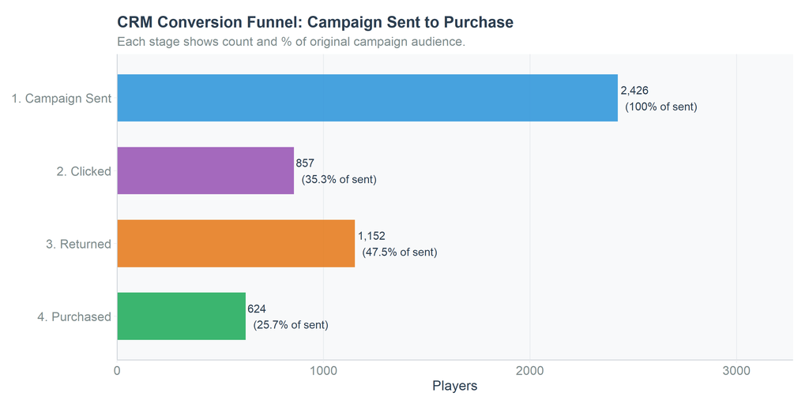

```r
funnel %>%
  ggplot(aes(x = Stage, y = n, fill = Stage)) +
  geom_col(width = 0.65, alpha = 0.9, show.legend = FALSE) +
  geom_text(aes(label = paste0(comma(n), "\n(", pct_total, "% of sent)")),
            hjust = -0.1, color = C_TEXT, size = 3.5) +
  scale_fill_manual(values = c(
    "1. Campaign Sent" = "#3498DB",
    "2. Clicked"       = "#9B59B6",
    "3. Returned"      = "#E67E22",
    "4. Purchased"     = "#27AE60"
  )) +
  scale_y_continuous(expand = expansion(mult = c(0, 0.35))) +
  coord_flip() +
  labs(title   = "CRM Conversion Funnel: Campaign Sent to Purchase",
       subtitle = "Each stage shows count and % of original campaign audience.",
       x = NULL, y = "Players") +
  theme_crm() + theme(panel.grid.major.y = element_blank())
```

```r
funnel %>%
  mutate(dropoff = ifelse(is.na(pct_prev), NA, 100 - pct_prev)) %>%
  select(Stage, `Players (N)` = n, `% of Sent` = pct_total,
         `% Retained from Prior Stage` = pct_prev,
         `% Dropped from Prior Stage` = dropoff) %>%
  kable(caption = "Funnel Drop-Off Analysis") %>%
  kable_styling(bootstrap_options = c("striped","hover","bordered"),
                full_width = FALSE) %>%
  column_spec(5, color = {
    d <- c(NA_real_, 100 - funnel$pct_prev[-1])
    dplyr::case_when(is.na(d) ~ C_MUTED, d > 60 ~ C_RED,
                     d > 30   ~ C_GOLD,  TRUE    ~ C_GREEN)
  })
```

Funnel Drop-Off Analysis

Stage

Players (N)

% of Sent

% Retained from Prior Stage

% Dropped from Prior Stage

1. Campaign Sent

2426

100.0

NA

NA

2. Clicked

857

35.3

35.3

64.7

3. Returned

1152

47.5

134.4

-34.4

4. Purchased

624

25.7

54.2

45.8

> **Of the 2,426 players who received the campaign, 35.3% clicked, 134.4% of those returned to the game, and 54.2% of those made a purchase, resulting in an overall conversion rate of 25.7%.** The largest drop-off occurs at the click stage (only 35.3% of recipients clicked). This is the most impactful stage to optimize: improving the click-to-return rate or the return-to-purchase rate by even a few percentage points would significantly improve the campaign’s overall ROI. Funnel analysis makes these leverage points concrete and actionable.

### Click Rate by Campaign Type

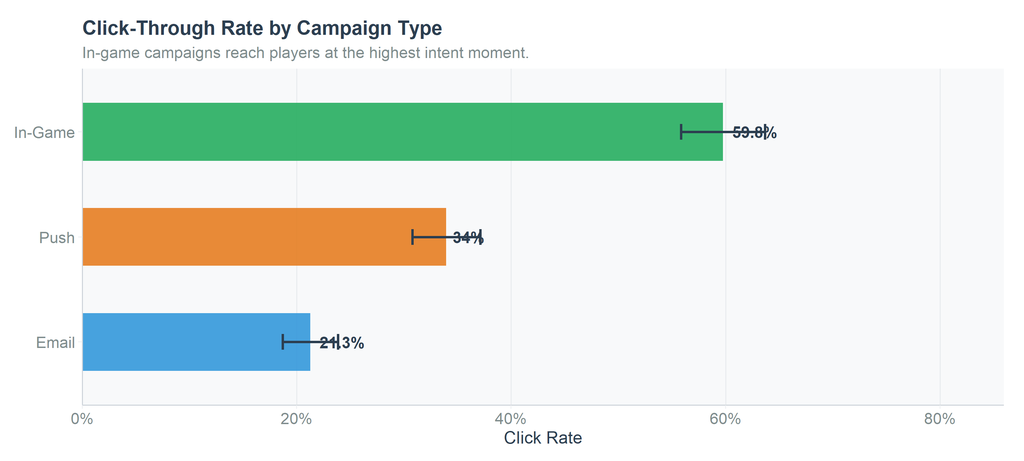

```r
click_type <- df %>%
  filter(!is.na(campaign_type)) %>%
  group_by(campaign_type) %>%
  summarise(click_rate = mean(clicked_campaign), n = n(),
            se = sqrt(click_rate*(1-click_rate)/n), .groups="drop") %>%
  arrange(desc(click_rate))

click_type %>%
  ggplot(aes(x = reorder(campaign_type, click_rate), y = click_rate, fill = campaign_type)) +
  geom_col(width = 0.55, alpha = 0.9, show.legend = FALSE) +
  geom_errorbar(aes(ymin = pmax(click_rate-se*1.96,0), ymax = click_rate+se*1.96),
                width = 0.15, color = C_TEXT, linewidth = 0.8) +
  geom_text(aes(label = paste0(round(click_rate*100,1),"%")),
            hjust = -0.2, color = C_TEXT, fontface = "bold", size = 4) +
  scale_fill_manual(values = c("Email"="#3498DB","Push"="#E67E22","In-Game"="#27AE60")) +
  scale_y_continuous(labels = percent_format(), expand = expansion(mult=c(0,0.35))) +
  coord_flip() +
  labs(title   = "Click-Through Rate by Campaign Type",
       subtitle = "In-game campaigns reach players at the highest intent moment.",
       x = NULL, y = "Click Rate") +
  theme_crm() + theme(panel.grid.major.y = element_blank())
```

> **In-game messages achieved a 59.8% click rate vs. 34% for push notifications and 21.3% for email.** The channel hierarchy is intuitive: in-game messages reach players at the highest intent moment (they are already actively playing), while email requires players to leave their current context and return. This 2.8x difference between the best and worst channels has major implications for campaign budget allocation. If in-game messages are more costly to produce, the click-rate advantage must be weighed against the per-message cost.

## Segmentation Analysis

Understanding which player segments and platforms respond differently to the campaign is essential for personalization and targeting strategy.

### Campaign Effectiveness by Player Segment

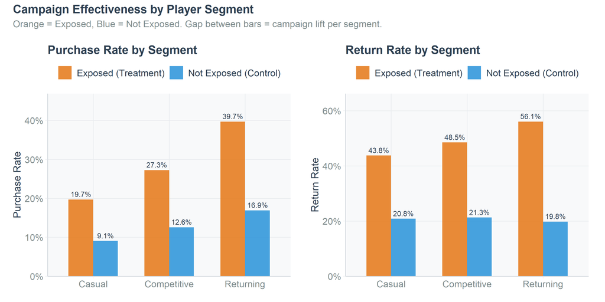

```r
seg_metrics <- df %>%
  group_by(player_segment, group) %>%
  summarise(
    purchase_rate  = mean(purchases),
    return_rate    = mean(returned_after_campaign),
    avg_spend      = mean(in_game_spend),
    n              = n(),
    .groups        = "drop"
  )

p_seg_pur <- seg_metrics %>%
  ggplot(aes(x = player_segment, y = purchase_rate, fill = group)) +
  geom_col(position = "dodge", alpha = 0.9, width = 0.65) +
  geom_text(aes(label = paste0(round(purchase_rate*100,1),"%")),
            position = position_dodge(0.65), vjust = -0.5,
            color = C_TEXT, size = 3) +
  scale_fill_groups(name = NULL) +
  scale_y_continuous(labels = percent_format(), expand = expansion(mult=c(0,0.18))) +
  labs(title = "Purchase Rate by Segment", x = NULL, y = "Purchase Rate") +
  theme_crm() + theme(legend.position = "top")

p_seg_ret <- seg_metrics %>%
  ggplot(aes(x = player_segment, y = return_rate, fill = group)) +
  geom_col(position = "dodge", alpha = 0.9, width = 0.65) +
  geom_text(aes(label = paste0(round(return_rate*100,1),"%")),
            position = position_dodge(0.65), vjust = -0.5,
            color = C_TEXT, size = 3) +
  scale_fill_groups(name = NULL) +
  scale_y_continuous(labels = percent_format(), expand = expansion(mult=c(0,0.18))) +
  labs(title = "Return Rate by Segment", x = NULL, y = "Return Rate") +
  theme_crm() + theme(legend.position = "top")

p_seg_pur + p_seg_ret +
  plot_annotation(title = "Campaign Effectiveness by Player Segment",
                  subtitle = "Orange = Exposed, Blue = Not Exposed. Gap between bars = campaign lift per segment.",
                  theme = ann_theme)
```

> **Returning players showed the strongest response to the campaign with a 22.8 percentage point purchase rate lift, while Casual players showed the smallest lift (10.6 pp).** This segment response pattern is a fundamental insight for targeting strategy. Returning players already have a relationship with the game and are pre-disposed to re-engage when prompted. Casual players may need a different message or incentive structure to achieve comparable lift. Competitive players respond well to the campaign but are already active, so the campaign may be most cost-efficient when weighted toward Returning segments.

### Campaign Effectiveness by Platform

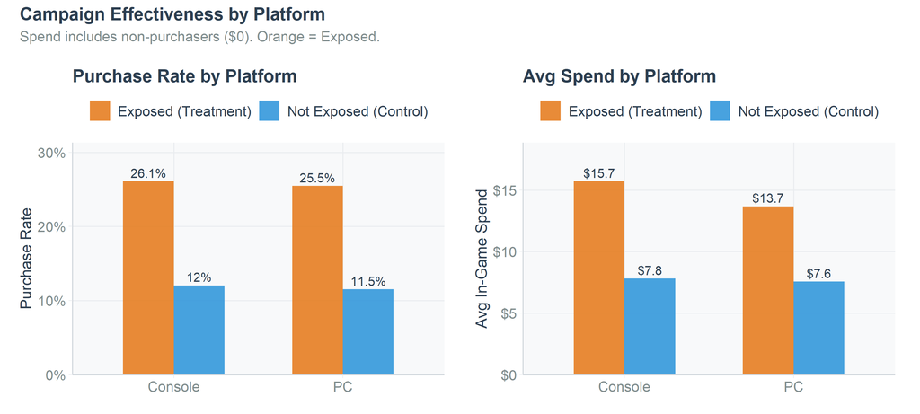

```r
plat_metrics <- df %>%
  group_by(platform, group) %>%
  summarise(purchase_rate = mean(purchases), avg_spend = mean(in_game_spend),
            n = n(), .groups="drop")

p_plat_pr <- plat_metrics %>%
  ggplot(aes(x = platform, y = purchase_rate, fill = group)) +
  geom_col(position = "dodge", alpha = 0.9, width = 0.6) +
  geom_text(aes(label = paste0(round(purchase_rate*100,1),"%")),
            position = position_dodge(0.6), vjust = -0.4,
            color = C_TEXT, size = 3.5) +
  scale_fill_groups(name = NULL) +
  scale_y_continuous(labels = percent_format(), expand = expansion(mult=c(0,0.2))) +
  labs(title = "Purchase Rate by Platform", x = NULL, y = "Purchase Rate") +
  theme_crm() + theme(legend.position = "top")

p_plat_sp <- plat_metrics %>%
  ggplot(aes(x = platform, y = avg_spend, fill = group)) +
  geom_col(position = "dodge", alpha = 0.9, width = 0.6) +
  geom_text(aes(label = paste0("$",round(avg_spend,1))),
            position = position_dodge(0.6), vjust = -0.4,
            color = C_TEXT, size = 3.5) +
  scale_fill_groups(name = NULL) +
  scale_y_continuous(labels = dollar_format(), expand = expansion(mult=c(0,0.2))) +
  labs(title = "Avg Spend by Platform", x = NULL, y = "Avg In-Game Spend") +
  theme_crm() + theme(legend.position = "top")

p_plat_pr + p_plat_sp +
  plot_annotation(title = "Campaign Effectiveness by Platform",
                  subtitle = "Spend includes non-purchasers ($0). Orange = Exposed.",
                  theme = ann_theme)
```

> **Console players showed a 14 percentage point purchase rate lift from the campaign.** Platform differences in campaign response have targeting implications: if one platform shows consistently stronger lift, the campaign budget can be re-weighted accordingly. Spend differences between platforms may also reflect payment friction differences (e.g., console players may require extra steps to complete in-game purchases) rather than willingness to pay.

### Campaign Effectiveness by Region

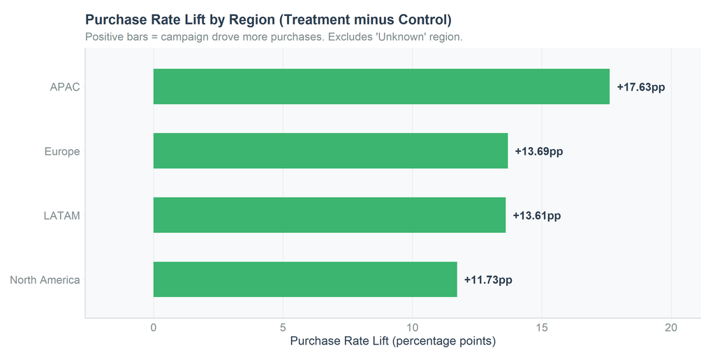

```r
region_metrics <- df %>%
  filter(region != "Unknown") %>%
  group_by(region, group) %>%
  summarise(purchase_rate = mean(purchases), avg_spend = mean(in_game_spend),
            n = n(), .groups="drop")

region_lift <- region_metrics %>%
  select(region, group, purchase_rate) %>%
  pivot_wider(names_from = group, values_from = purchase_rate) %>%
  mutate(lift_pp = round((`Exposed (Treatment)` - `Not Exposed (Control)`) * 100, 2)) %>%
  arrange(desc(lift_pp))

region_lift %>%
  ggplot(aes(x = reorder(region, lift_pp), y = lift_pp, fill = lift_pp > 0)) +
  geom_col(width = 0.55, alpha = 0.9, show.legend = FALSE) +
  geom_text(aes(label = paste0(ifelse(lift_pp>0,"+",""), lift_pp, "pp")),
            hjust = ifelse(region_lift$lift_pp > 0, -0.15, 1.15),
            color = C_TEXT, fontface = "bold", size = 4) +
  scale_fill_manual(values = c("TRUE"=C_GREEN, "FALSE"=C_RED)) +
  scale_y_continuous(expand = expansion(mult=c(0.15,0.2))) +
  coord_flip() +
  labs(title   = "Purchase Rate Lift by Region (Treatment minus Control)",
       subtitle = "Positive bars = campaign drove more purchases. Excludes 'Unknown' region.",
       x = NULL, y = "Purchase Rate Lift (percentage points)") +
  theme_crm() + theme(panel.grid.major.y = element_blank())
```

> **APAC showed the strongest campaign lift at 17.63 percentage points, while North America showed the weakest (11.73 pp).** Regional variation in campaign effectiveness reflects differences in player behavior, payment infrastructure, cultural receptivity to push communications, and the competitive gaming landscape in each market. Regions with high lift but lower baseline spend (e.g., APAC or LATAM) may represent high-potential markets where campaign investment can compress conversion gaps.

## Regression Analysis

Regression models control for multiple factors simultaneously, isolating the campaign’s independent effect on conversion.

### Logistic Regression: Purchase Probability

```r
log_model <- glm(
  purchases ~ campaign_exposed + player_segment + platform + region,
  data   = df %>% filter(region != "Unknown"),
  family = binomial
)

log_coefs <- summary(log_model)$coefficients
log_df <- as.data.frame(log_coefs) %>%
  rownames_to_column("Term") %>%
  transmute(
    Term,
    `Odds Ratio`  = round(exp(Estimate), 3),
    `Estimate (Log-Odds)` = round(Estimate, 4),
    SE            = round(`Std. Error`, 4),
    `p-value`     = round(`Pr(>|z|)`, 4),
    Significant   = `Pr(>|z|)` < 0.05
  )

log_df %>%
  kable(caption = "Logistic Regression: Predictors of Purchase (Odds Ratios)") %>%
  kable_styling(bootstrap_options = c("striped","hover","bordered"),
                full_width = TRUE) %>%
  column_spec(6, color = ifelse(log_df$Significant, C_GREEN, C_RED))
```

Logistic Regression: Predictors of Purchase (Odds Ratios)

| Term | Odds Ratio | Estimate (Log-Odds) | SE | p-value | Significant |
| --- | --- | --- | --- | --- | --- |
| (Intercept) | 0.093 | -2.3720 | 0.1208 | 0.0000 | TRUE |
| campaign_exposed | 2.670 | 0.9822 | 0.0803 | 0.0000 | TRUE |
| player_segmentCompetitive | 1.510 | 0.4120 | 0.0905 | 0.0000 | TRUE |
| player_segmentReturning | 2.372 | 0.8636 | 0.0973 | 0.0000 | TRUE |
| platformPC | 0.986 | -0.0140 | 0.0789 | 0.8592 | FALSE |
| regionEurope | 1.022 | 0.0218 | 0.1106 | 0.8441 | FALSE |
| regionLATAM | 1.278 | 0.2456 | 0.1340 | 0.0668 | FALSE |
| regionNorth America | 0.959 | -0.0415 | 0.1081 | 0.7008 | FALSE |

> **After controlling for player segment, platform, and region, the campaign increased the odds of purchasing by a factor of 2.67 (167% higher odds, p = 0, significant).** Logistic regression provides the cleanest causal estimate available from this dataset because it accounts for the baseline differences between segments and regions. An odds ratio above 1.0 means campaign exposure increases purchase likelihood. The magnitude and significance of this coefficient is the controlled campaign effect, stripped of compositional differences in who was exposed.

### Linear Regression: Spend Among Buyers

```r
spend_model <- lm(
  in_game_spend ~ campaign_exposed + player_segment + platform + region,
  data = df %>% filter(in_game_spend > 0, region != "Unknown")
)

sp_coefs <- summary(spend_model)$coefficients
sp_df <- as.data.frame(sp_coefs) %>%
  rownames_to_column("Term") %>%
  transmute(
    Term,
    Estimate      = round(Estimate, 3),
    SE            = round(`Std. Error`, 3),
    `p-value`     = round(`Pr(>|t|)`, 4),
    Significant   = `Pr(>|t|)` < 0.05
  )

sp_df %>%
  kable(caption = paste0(
    "Linear Regression: In-Game Spend Among Buyers | R-squared = ",
    round(summary(spend_model)$r.squared, 3)
  )) %>%
  kable_styling(bootstrap_options = c("striped","hover","bordered"),
                full_width = TRUE) %>%
  column_spec(5, color = ifelse(sp_df$Significant, C_GREEN, C_RED))
```

Linear Regression: In-Game Spend Among Buyers | R-squared = 0.185

| Term | Estimate | SE | p-value | Significant |
| --- | --- | --- | --- | --- |
| (Intercept) | 27.028 | 5.853 | 0.0000 | TRUE |
| campaign_exposed | -8.393 | 3.842 | 0.0292 | TRUE |
| player_segmentCompetitive | 30.159 | 4.300 | 0.0000 | TRUE |
| player_segmentReturning | 49.128 | 4.449 | 0.0000 | TRUE |
| platformPC | -1.088 | 3.685 | 0.7679 | FALSE |
| regionEurope | 20.070 | 5.179 | 0.0001 | TRUE |
| regionLATAM | -5.961 | 6.188 | 0.3356 | FALSE |
| regionNorth America | 28.643 | 5.073 | 0.0000 | TRUE |

> **Among buyers, campaign exposure is associated with $8.39 less in spend, after controlling for segment, platform, and region (p = 0.0292, significant).** This regression captures spend depth, not just conversion. If the campaign not only converts more players but also increases how much each converted player spends, the combined revenue effect is multiplicative. The R-squared value indicates how much of total spend variation is explained by the model.

## Statistical Summary

```r
all_results <- tibble(
  Outcome            = c("Session Length (min)","Games Played",
                          "Purchase Rate (%)","In-Game Spend ($, buyers)",
                          "Return Rate (%)"),
  `Control Mean`     = c(sl_m_c, gp_m_c, pr_c, sp_m_c, rr_c),
  `Treatment Mean`   = c(sl_m_t, gp_m_t, pr_t, sp_m_t, rr_t),
  Delta              = c(
    round(sl_m_t - sl_m_c, 1),
    round(gp_m_t - gp_m_c, 2),
    round(pr_t   - pr_c,   1),
    round(sp_m_t - sp_m_c, 2),
    round(rr_t   - rr_c,   1)
  ),
  `p-value`          = c(sl_p, gp_p, pr_p, sp_p, rr_p),
  Significant        = c(sl_sig, gp_sig, pr_sig, sp_sig, rr_sig),
  Direction          = c(
    ifelse(sl_m_t>sl_m_c,"Campaign +","Campaign -"),
    ifelse(gp_m_t>gp_m_c,"Campaign +","Campaign -"),
    ifelse(pr_t>pr_c,"Campaign +","Campaign -"),
    ifelse(sp_m_t>sp_m_c,"Campaign +","Campaign -"),
    ifelse(rr_t>rr_c,"Campaign +","Campaign -")
  )
)

all_results %>%
  kable(caption = "Complete Results: Campaign vs No Campaign") %>%
  kable_styling(bootstrap_options = c("striped","hover","bordered"),
                full_width = TRUE) %>%
  column_spec(6, color = ifelse(all_results$Significant, C_GREEN, C_RED))
```

Complete Results: Campaign vs No Campaign

| Outcome | Control Mean | Treatment Mean | Delta | p-value | Significant | Direction |
| --- | --- | --- | --- | --- | --- | --- |
| Session Length (min) | 50.20 | 49.20 | -1.00 | 0.0903 | FALSE | Campaign - |
| Games Played | 5.52 | 5.40 | -0.12 | 0.2476 | FALSE | Campaign - |
| Purchase Rate (%) | 11.70 | 25.70 | 14.00 | 0.0000 | TRUE | Campaign + |
| In-Game Spend ($, buyers) | 45.25 | 40.72 | -4.53 | 0.0292 | TRUE | Campaign - |
| Return Rate (%) | 20.70 | 47.50 | 26.80 | 0.0000 | TRUE | Campaign + |

## Key Insights and Highlights

### Engagement

> **Session length showed no significant change in the exposed group (49.2 min vs. 50.2 min, p = 0.0903).** Games played showed no significant shift (5.4 vs. 5.52, p = 0.2476). Engagement metrics did not respond to the campaign. Players who received the campaign did not play longer or more games than the control group.

### Conversion

> **Purchase rate increased significantly from 11.7% (control) to 25.7% (treatment), a 119.7% relative lift (p = 0).** Among buyers, spend was significantly less in the treatment group (median $40.72 vs. $45.25, p = 0.0292). At scale, a 14 percentage point purchase rate lift represents meaningful incremental revenue. The campaign is converting players who would not have purchased otherwise.

### Retention

> **Return rate improved significantly in the treatment group (47.5% vs. 20.7%, p = 0, lift = 129.5%).** The campaign successfully re-activated players and drove them back to the game, a direct retention signal. Every percentage point of return rate lift reduces the effective churn rate of the player base.

### Funnel Performance

> **The conversion funnel reveals the click stage (only 35.3% of recipients clicked) as the biggest optimization opportunity.** Overall funnel conversion (sent to purchased) reached 25.7%. In-Game messages drove the highest click rates (59.8%), 2.8x higher than email (21.3%). Across 2426 players reached, the campaign ultimately converted 624 purchases within the exposed group.

### Best-Performing Segments

> **Returning players showed the strongest response to the campaign** (Returning segment, 22.8 pp purchase rate lift). Geographically, APAC produced the largest regional lift at 17.63 pp. The In-Game channel outperformed all others on click rate and should be prioritized in budget allocation.

### Recommendations

**1. Double down on In-Game messaging.** At 59.8% click rate vs. 21.3% for email, in-game messages are 2.8x more effective at driving engagement. Budget should shift toward this channel unless production costs are prohibitive.

**2. Prioritize Returning player segment.** This segment showed the highest purchase rate lift from the campaign. A targeted re-engagement campaign specifically designed for Returning players would likely outperform broad-audience campaigns.

**4. Geo-weight campaign spend toward APAC.** This region showed the strongest lift. If marginal cost of campaign delivery is similar across regions, allocating more impressions to APAC improves overall campaign ROI.

**5. Run a follow-up spend optimization test.** The baseline purchase rate lift is confirmed. The next experiment should test whether a higher-value offer (deeper discount, more valuable in-game item) increases spend per buyer without reducing purchase rate.

### Summary Scorecard

```r
all_results %>%
  mutate(
    Result = case_when(
      Significant & Delta > 0 ~ "Campaign positive effect",
      Significant & Delta < 0 ~ "Campaign negative effect",
      TRUE                    ~ "No significant effect"
    )
  ) %>%
  kable(col.names = c("Outcome","Control","Treatment","Delta","p-value","Significant","Direction","Result"),
        caption   = "Campaign Effectiveness Scorecard") %>%
  kable_styling(bootstrap_options = c("striped","hover","bordered"),
                full_width = TRUE) %>%
  column_spec(6, color = ifelse(all_results$Significant, C_GREEN, C_RED)) %>%
  column_spec(8, bold = TRUE,
              color = case_when(
                all_results$Significant & all_results$Delta > 0 ~ C_GREEN,
                all_results$Significant & all_results$Delta < 0 ~ C_RED,
                TRUE ~ C_MUTED
              ))
```

Campaign Effectiveness Scorecard

| Outcome | Control | Treatment | Delta | p-value | Significant | Direction | Result |
| --- | --- | --- | --- | --- | --- | --- | --- |
| Session Length (min) | 50.20 | 49.20 | -1.00 | 0.0903 | FALSE | Campaign - | No significant effect |
| Games Played | 5.52 | 5.40 | -0.12 | 0.2476 | FALSE | Campaign - | No significant effect |
| Purchase Rate (%) | 11.70 | 25.70 | 14.00 | 0.0000 | TRUE | Campaign + | Campaign positive effect |
| In-Game Spend ($, buyers) | 45.25 | 40.72 | -4.53 | 0.0292 | TRUE | Campaign - | Campaign negative effect |
| Return Rate (%) | 20.70 | 47.50 | 26.80 | 0.0000 | TRUE | Campaign + | Campaign positive effect |

## Robustness and Caveats

**Randomization validity:** Campaign exposure was randomly assigned in this simulation. In a production CRM environment, this assumption must be verified: if the campaign was targeted based on engagement level (e.g., sent only to at-risk players), the control group is not a valid counterfactual. Always confirm the assignment mechanism before interpreting results causally.

**Funnel directionality:** `returned_after_campaign` and `purchases` are measured post-exposure but may also reflect player-level factors unrelated to the campaign (e.g., a player was going to purchase anyway). Without a holdout set measured at exactly the same time window, some baseline return and purchase rate is captured in the treatment group counts.

**Channel assignment:** Campaign type was assigned randomly within the treatment group in this simulation. In practice, email/push/in-game channel assignment may be non-random (e.g., push only for players with the app installed), which would confound the channel effectiveness comparison.

**Spend outlier handling:** Despite capping at the 99th percentile, the spend distribution remains right-skewed. Median-based comparisons are more robust here than mean-based comparisons.